# Suavizacao e Decomposicao

### STL s.window e t.window

- `s.window`: tamanho da janela de ajuste para **sazonalidade**.  
  Menores valores produzem mudanças de sazonalidade mais rápidas.  
  Se `s.window = "periodic"`, então é utilizada a média.  
  Cleveland et al. (1990) sugere que seja usado pelo menos 7;
- `t.window`: tamanho da janela de ajuste para **tendência**.  
  Menores valores produzem mudanças de tendência mais rápidas;

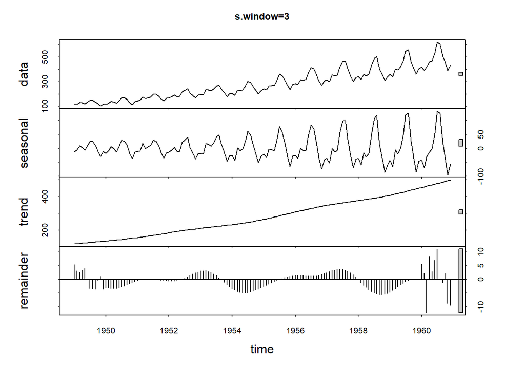

```r
x <- AirPassengers

##### variando s.window ########
stl(x, s.window=3) %>% plot( main='s.window=3' )
```

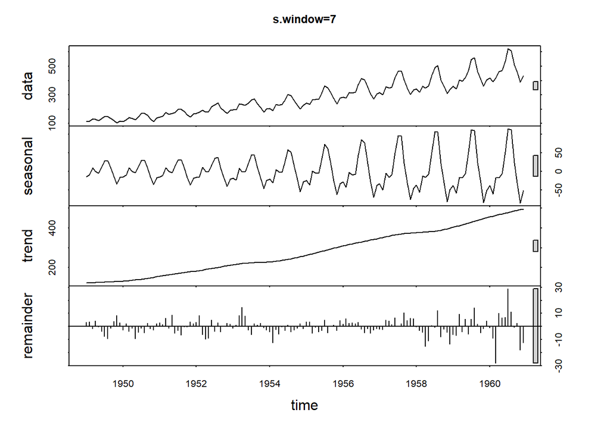

```r
stl(x, s.window=7) %>% plot( main='s.window=7' )
```

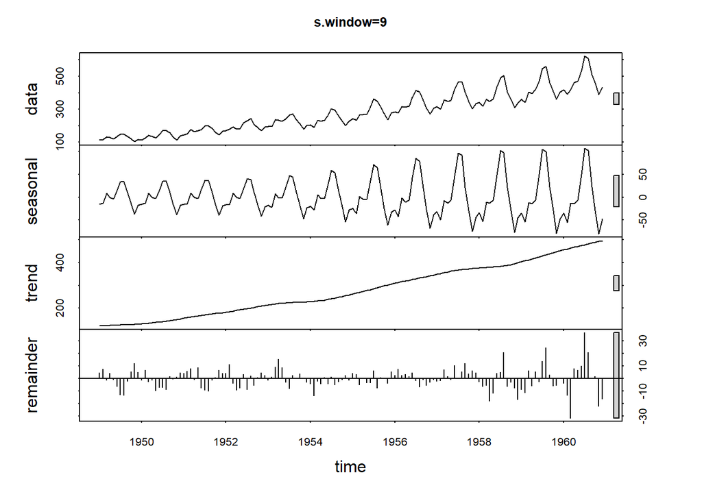

```r
stl(x, s.window=9) %>% plot( main='s.window=9' )
```

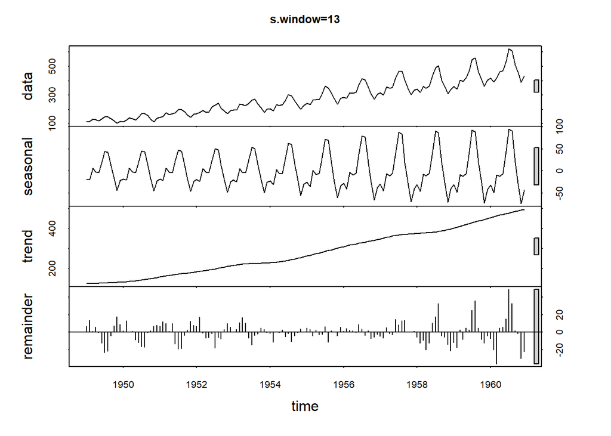

```r
stl(x, s.window=13) %>% plot( main='s.window=13' )
```

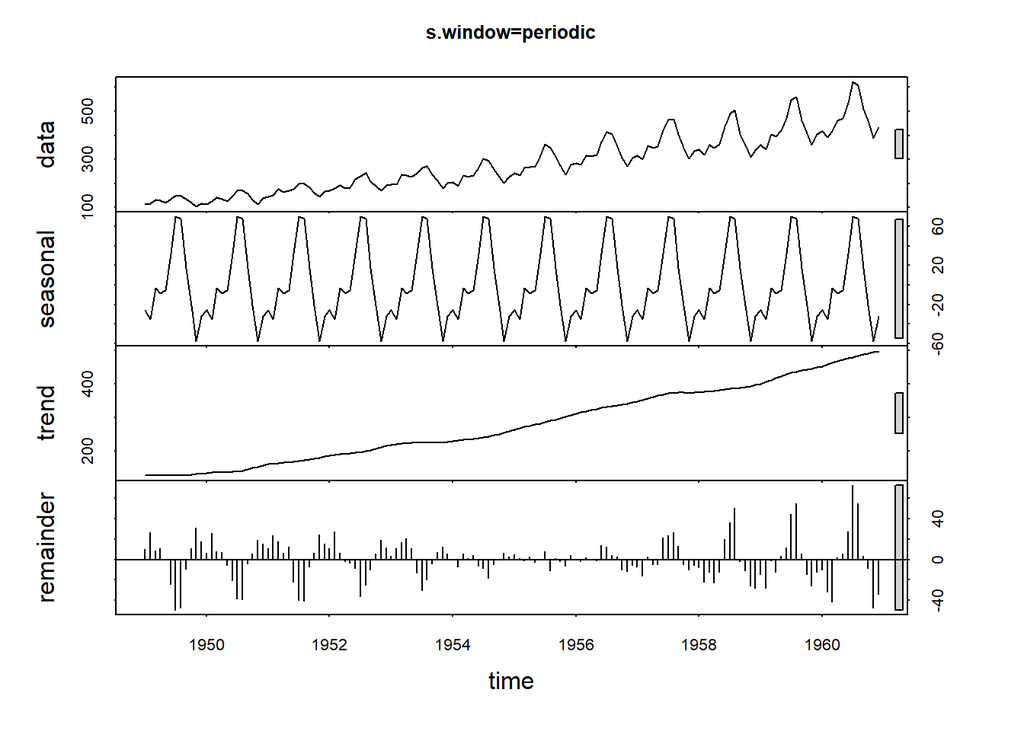

```r
stl(x, s.window='periodic') %>% plot( main='s.window=periodic' ) #pegamos a media da serie ou seja nao captamos a amplitude da sazonalidade que muda com o tempo
```

### Aplicando a decomposicao STL

#### UKgas

- O que é: consumo trimestral de gás no Reino Unido.
- Período aproximado: 1960–1986.
- Frequência: 4 (trimestres).
- O que observar: tendência de longo prazo (expansão do consumo ao longo dos anos) e sazonalidade trimestral bem marcada (invernos vs. verões).

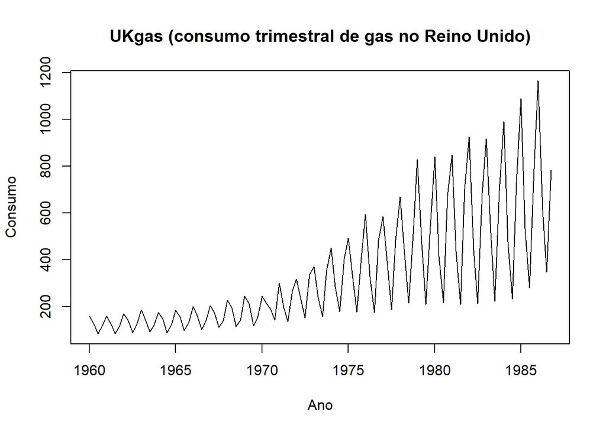

```r
plot(UKgas, main = "UKgas (consumo trimestral de gas no Reino Unido)", ylab = "Consumo", xlab = "Ano")
```

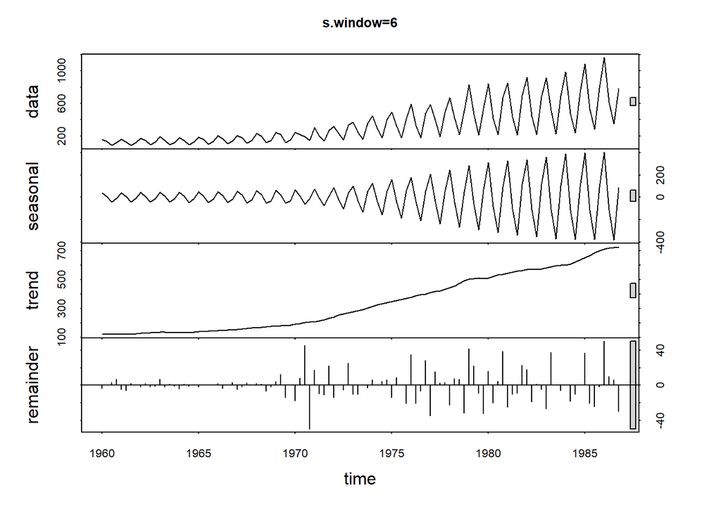

```r
stl(UKgas, s.window=6) %>% plot( main='s.window=6' )
```

#### USAccDeaths

- O que é: número de mortes mensais por acidentes automobilísticos nos EUA.
- Período aproximado: 1973–1978.
- Frequência: 12 (mensal).
- O que observar: sazonalidade anual (picos nos meses mais movimentados/condições sazonais) e alguma variação de nível ao longo dos anos.

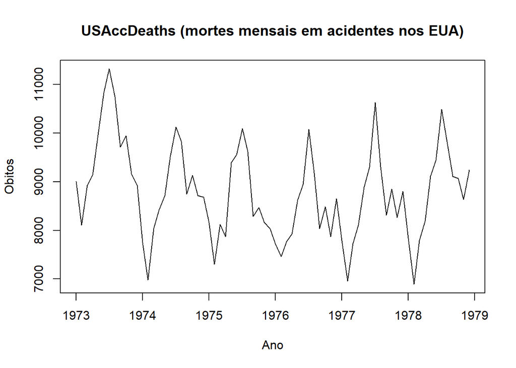

```r
plot(USAccDeaths, main = "USAccDeaths (mortes mensais em acidentes nos EUA)", ylab = "Obitos", xlab = "Ano")
```

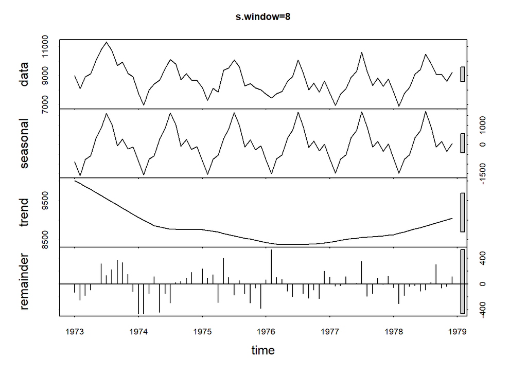

```r
stl(USAccDeaths, s.window=8) %>% plot( main='s.window=8' )
```

#### co2

- O que é: concentração mensal de CO₂ atmosférico medida em Mauna Loa (Havaí).
- Período aproximado: 1959–1997.
- Frequência: 12 (mensal).
- O que observar: forte tendência de alta (acúmulo de CO₂ ao longo das décadas) e padrão sazonal anual (oscilações “dente-de-serra” por ciclos vegetativos do hemisfério norte).

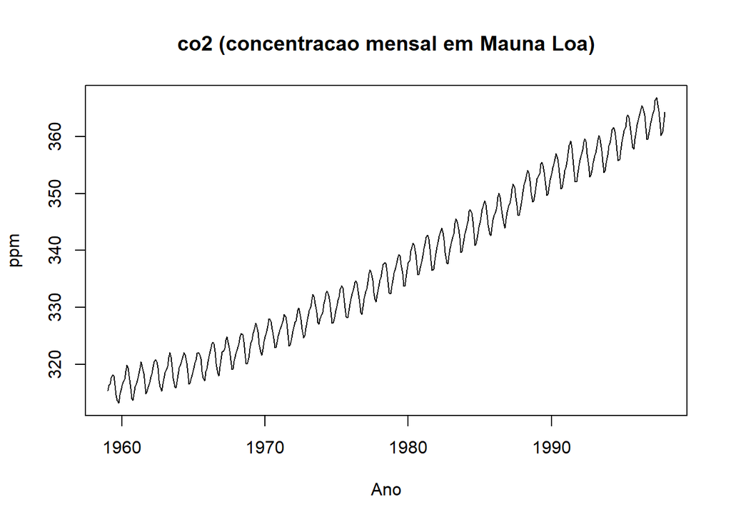

```r
plot(co2, main = "co2 (concentracao mensal em Mauna Loa)", ylab = "ppm", xlab = "Ano")
```

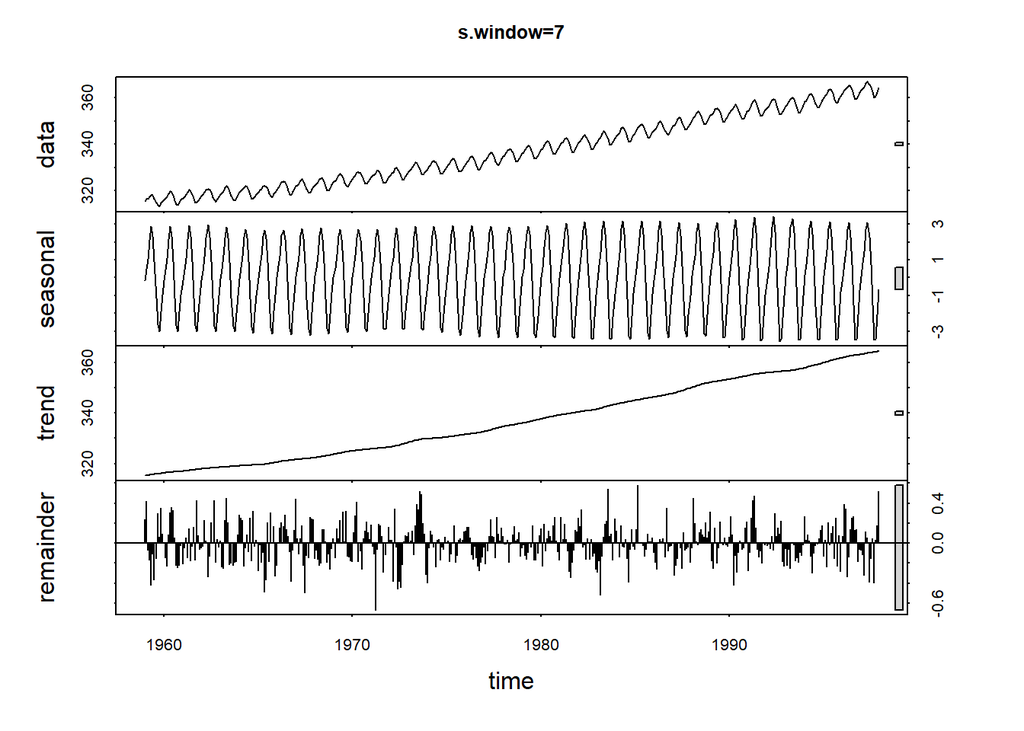

```r
stl(co2, s.window=7) %>% plot( main='s.window=7' )
```